# R Notebook

```r
library(tidyverse)
```

## An example data set - General Social Survey

| year | marital | age | race | rincome | partyid | relig | denom | tvhours |
| --- | --- | --- | --- | --- | --- | --- | --- | --- |
| 2000 | Never married | 26 | White | $8000 to 9999 | Ind,near rep | Protestant | Southern baptist | 12 |
| 2000 | Divorced | 48 | White | $8000 to 9999 | Not str republican | Protestant | Baptist-dk which | NA |
| 2000 | Widowed | 67 | White | Not applicable | Independent | Protestant | No denomination | 2 |
| 2000 | Never married | 39 | White | Not applicable | Ind,near rep | Orthodox-christian | Not applicable | 4 |
| 2000 | Divorced | 25 | White | Not applicable | Not str democrat | None | Not applicable | 1 |
| 2000 | Married | 25 | White | $20000 - 24999 | Strong democrat | Protestant | Southern baptist | NA |
| 2000 | Never married | 36 | White | $25000 or more | Not str republican | Christian | Not applicable | 3 |
| 2000 | Divorced | 44 | White | $7000 to 7999 | Ind,near dem | Protestant | Lutheran-mo synod | NA |
| 2000 | Married | 44 | White | $25000 or more | Not str democrat | Protestant | Other | 0 |
| 2000 | Married | 47 | White | $25000 or more | Strong republican | Protestant | Southern baptist | 3 |

[output cut: 990 more lines]

When factors are stored in a tibble, you can’t see their levels so easily. One way to see them is with `count()`:

```r
gss_cat %>%
  count(race)
```

| race | n |
| --- | --- |
| Other | 1959 |
| Black | 3129 |
| White | 16395 |

By default, ggplot2 will drop levels that don’t have any values. You can force them to display with:

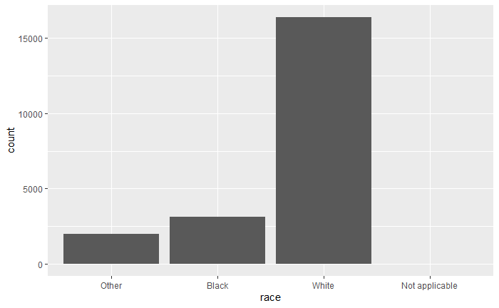

```r
ggplot(gss_cat, aes(race)) + geom_bar() + scale_x_discrete(drop = FALSE)
```

## 1.2 Modifying factor order

It’s often useful to change the order of the factor levels in a visualisation. For example, imagine you want to explore the average number of hours spent watching TV per day across religions:

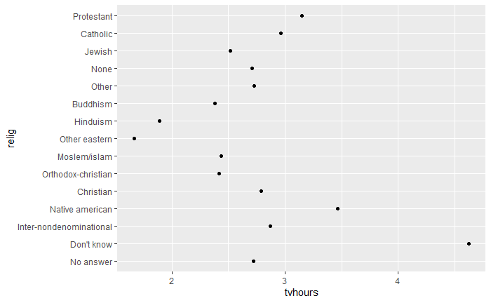

```r
relig_summary <- gss_cat %>%
      group_by(relig) %>%
      summarise(
        age = mean(age, na.rm = TRUE),
        tvhours = mean(tvhours, na.rm=TRUE),
        n = n()
      )

ggplot(relig_summary, aes(x=tvhours, y=relig)) + geom_point()
```

It is difficult to interpret this plot because there’s no overall pattern. We can improve it by reordering the levels of relig using `fct_reorder()`. `fct_reorder()` takes three arguments:

1. `f`, the factor whose levels you want to modify.
2. `x`, a numeric vector that you want to use to reorder the levels.
3. Optionally, `fun`, a function that’s used if there are multiple values of `x` for each value of `f`. The default value is median.

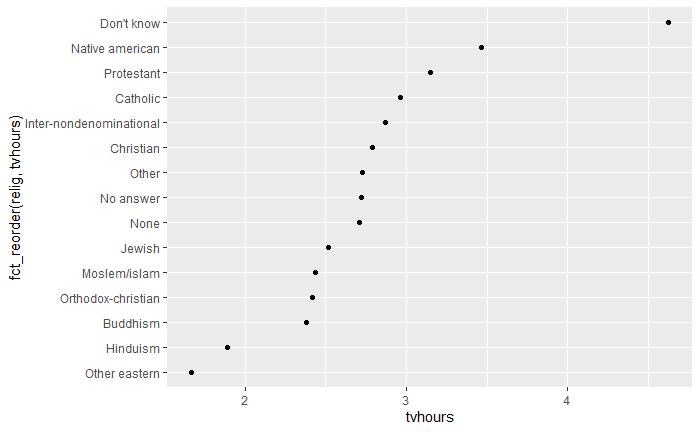

```r
ggplot(relig_summary, aes(tvhours, fct_reorder(relig, tvhours))) + geom_point()
```

A better way to write:

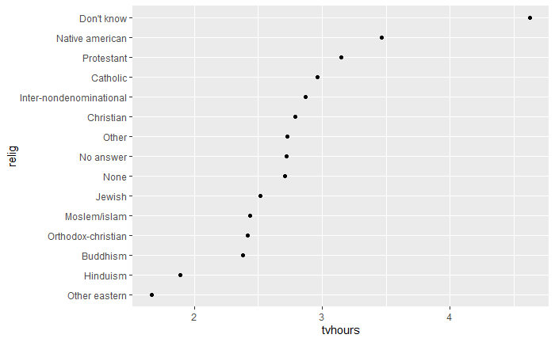

```r
relig_summary %>%
  mutate(relig = fct_reorder(relig, tvhours)) %>%
  ggplot(aes(tvhours, relig)) +
  geom_point()
```

Another type of reordering is useful when you are colouring the lines on a plot. `fct_reorder2()` reorders the factor by the y values associated with the largest x values. This makes the plot easier to read because the line colours line up with the legend.

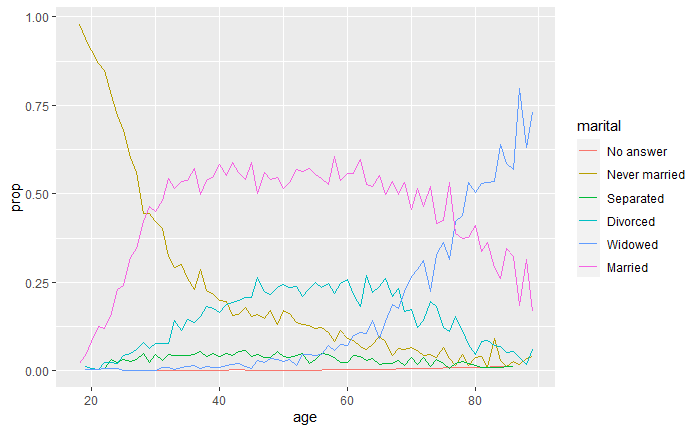

```r
by_age <- gss_cat %>%
  filter(!is.na(age)) %>%
  count(age, marital) %>%
  group_by(age) %>%
  mutate(prop = n / sum(n))


ggplot(by_age, aes(age, prop, color = marital)) + geom_line(na.rm = TRUE)
```

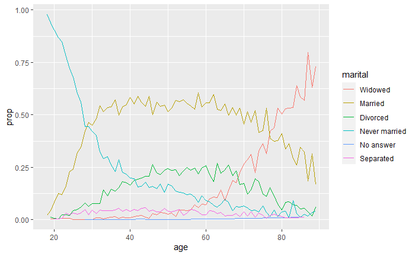

```r
ggplot(by_age, aes(age, prop, color = fct_reorder2(marital, age, prop))) +  geom_line() +
  labs(colour = "marital")
```

## 1.3 Modifying factor levels

More powerful than changing the orders of the levels is changing their values. This allows you to clarify labels for publication, and collapse levels for high-level displays. The most general and powerful tool is `fct_recode()`.

Original partyid:

```r
gss_cat %>% count(partyid)
```

| partyid | n |
| --- | --- |
| No answer | 154 |
| Don't know | 1 |
| Other party | 393 |
| Strong republican | 2314 |
| Not str republican | 3032 |
| Ind,near rep | 1791 |
| Independent | 4119 |
| Ind,near dem | 2499 |
| Not str democrat | 3690 |
| Strong democrat | 3490 |

After tweaking by `fct_recode` with a parallel construction:

```r
gss_cat %>%
  mutate(partyid = fct_recode(partyid,
    "Republican, strong"    = "Strong republican",
    "Republican, weak"      = "Not str republican",
    "Independent, near rep" = "Ind,near rep",
    "Independent, near dem" = "Ind,near dem",
    "Democrat, weak"        = "Not str democrat",
    "Democrat, strong"      = "Strong democrat"
  )) %>%
  count(partyid)
```

| partyid | n |
| --- | --- |
| No answer | 154 |
| Don't know | 1 |
| Other party | 393 |
| Republican, strong | 2314 |
| Republican, weak | 3032 |
| Independent, near rep | 1791 |
| Independent | 4119 |
| Independent, near dem | 2499 |
| Democrat, weak | 3690 |
| Democrat, strong | 3490 |

To combine groups, you can assign multiple old levels to the same new level:

```r
gss_cat %>%
  mutate(partyid = fct_recode(partyid,
    "Republican, strong"    = "Strong republican",
    "Republican, weak"      = "Not str republican",
    "Independent, near rep" = "Ind,near rep",
    "Independent, near dem" = "Ind,near dem",
    "Democrat, weak"        = "Not str democrat",
    "Democrat, strong"      = "Strong democrat",
    "Other"                 = "No answer",
    "Other"                 = "Don't know",
    "Other"                 = "Other party"
  )) %>%
  count(partyid)
```

| partyid | n |
| --- | --- |
| Other | 548 |
| Republican, strong | 2314 |
| Republican, weak | 3032 |
| Independent, near rep | 1791 |
| Independent | 4119 |
| Independent, near dem | 2499 |
| Democrat, weak | 3690 |
| Democrat, strong | 3490 |

If you want to collapse a lot of levels, `fct_collapse()` is a useful variant of `fct_recode()`. For each new variable, you can provide a vector of old levels: (combining multiple levels together)

```r
gss_cat %>%
  mutate(partyid = fct_collapse(partyid,
    other = c("No answer", "Don't know", "Other party"),
    rep = c("Strong republican", "Not str republican"),
    ind = c("Ind,near rep", "Independent", "Ind,near dem"),
    dem = c("Not str democrat", "Strong democrat")
  )) %>%
  count(partyid)
```

| partyid | n |
| --- | --- |
| other | 548 |
| rep | 5346 |
| ind | 8409 |
| dem | 7180 |